# Język R

## Postawowe informacje

Język programowania oraz implementujący go system R jest środowiskiem do statystycznej analizy danych. Umożliwia pracę interaktywną i skryptową.

Instalacja na Ubuntu:

`apt-get install r-base`

Jak dodać kernel R do Jupitera:

https://datatofish.com/r-tutorials/

Linki:

- Strona główna projektu R: http://www.r-project.org/
- Quick R: http://www.statmethods.net/
- RStudio: https://www.rstudio.com/
- R for Data Science: https://r4ds.had.co.nz/
- R Packages (zaawansowana): https://r-pkgs.org/
- ggplot2: https://ggplot2-book.org/

## Interaktywna praca z systemem

Jest kilka możliwości:

- Uruchamiamy RStudio, które zawiera zintegrowane środowisko do analizy danych w języku R
- Można też uruchomić konsolę R bezpośrednio poleceniem R
- W Jupyter tworzymy nowy notatnik z kernelem R

### Instalacja pakietów

`tidyverse` to zbiór kilku użytecznych pakietów, m.in. `dplyr` i `ggplot`. Więcej na https://www.tidyverse.org/packages/

Na https://jupyter.lab.ii.agh.edu.pl/ pakiet jest już zainstalowany.

```r
#install.packages('tidyverse')
#albo dla Anacondy anaconda.org/r/r-tidyverse
#w terminalu conda install -c r r-tidyverse
```

```r
# pokazuje też ewentualne "przykrycia"
library("tidyverse")
```

### R

Wbudowana pomoc:

```r
help()
```

```r
help(plot)
```

bieżący katalog

```r
getwd()
```

'C:/Users/kzaja/mownit24/mownit'

zmiana katalogu bieżącego

```
setwd("~")
```

#### Proste obliczenia

```r
2+2
```

4

Przypisanie

więcej o rodzajach przypisania: http://stat.ethz.ch/R-manual/R-patched/library/base/html/assignOps.html

```r
a <- 2 # najczęściej stosowane
```

```r
a = 2
```

Działanie:

```r
a * 2
```

4

#### Wektory

Tworzenie wektorów - funkcja `c()`

```r
x <- c(1,2,3,4)
z <- x*2
z
```

1. 2

2. 4

3. 6

4. 8

```r
y <- 2*(1:4)
x+y
```

1. 3

2. 6

3. 9

4. 12

Funkcje

```r
seq(1, 10, 2)
```

1. 1

2. 3

3. 5

4. 7

5. 9

```r
x <- seq(1, 10)
```

```r
sum(x)
```

55

```r
sqrt(x)
```

1. 1

2. 1.4142135623731

3. 1.73205080756888

4. 2

5. 2.23606797749979

6. 2.44948974278318

7. 2.64575131106459

8. 2.82842712474619

9. 3

10. 3.16227766016838

## Import i przekształcanie danych

R umożliwia wczytywanie danych z baz danych i plików w różnych formatach.

Przykład: import z pliku CSV.

Do importu służy funkcja `read.csv`

Przykładowy plik: data1.txt

Kolumny `t1` i `t2` zawierają wyniki "pomiarów" czasu dla 2 "algorytmów".

```r
results = read.csv("data1.txt")
```

Zaimportowane dane są w postaci tabeli (data frame).

```r
results
```

| n | t1 | t2 |
| --- | --- | --- |
| 1 | 1.1 | 2.3 |
| 2 | 2.0 | 4.1 |
| 3 | 2.8 | 6.0 |
| 4 | 4.2 | 8.2 |
| 5 | 5.1 | 9.9 |
| 6 | 5.9 | 12.1 |
| 7 | 6.7 | 14.1 |
| 8 | 8.0 | 15.9 |
| 9 | 9.1 | 18.1 |
| 10 | 10.1 | 19.9 |

```r
print(results)
```

```
    n   t1   t2
1   1  1.1  2.3
2   2  2.0  4.1
3   3  2.8  6.0
4   4  4.2  8.2
5   5  5.1  9.9
6   6  5.9 12.1
7   7  6.7 14.1
8   8  8.0 15.9
9   9  9.1 18.1
10 10 10.1 19.9
```

Pobranie kolumny (data frame):

```r
results[1]
```

| n |
| --- |
| 1 |
| 2 |
| 3 |
| 4 |
| 5 |
| 6 |
| 7 |
| 8 |
| 9 |
| 10 |

Pobranie kolumny jako wektor:

```r
results[[1]]
```

1. 1

2. 2

3. 3

4. 4

5. 5

6. 6

7. 7

8. 8

9. 9

10. 10

pobranie kolumny po nazwie:

```r
results["t1"]
```

| t1 |
| --- |
| 1.1 |
| 2.0 |
| 2.8 |
| 4.2 |
| 5.1 |
| 5.9 |
| 6.7 |
| 8.0 |
| 9.1 |
| 10.1 |

Pobranie wiersza lub wierszy:

```r
results[2,] # drugi wiersz, wszystkie kolumny
```

|  | n | t1 | t2 |
| --- | --- | --- | --- |
| 2 | 2 | 2 | 4.1 |

```r
results[c(2,4,6),]
```

|  | n | t1 | t2 |
| --- | --- | --- | --- |
| 2 | 2 | 2.0 | 4.1 |
| 4 | 4 | 4.2 | 8.2 |
| 6 | 6 | 5.9 | 12.1 |

`attach` (dodanie tabeli do kontekstu) pozwala na pojedyncze odwołania do kolumn (jako wektorów) bez odwoływania sie do calej tabeli:

```r
attach(results)

t1
```

1. 1.1

2. 2

3. 2.8

4. 4.2

5. 5.1

6. 5.9

7. 6.7

8. 8

9. 9.1

10. 10.1

```r
t2
```

1. 2.3

2. 4.1

3. 6

4. 8.2

5. 9.9

6. 12.1

7. 14.1

8. 15.9

9. 18.1

10. 19.9

```r
n
```

1. 1

2. 2

3. 3

4. 4

5. 5

6. 6

7. 7

8. 8

9. 9

10. 10

```r
detach(results)
```

```r
# generuje blad
t1
```

```
Error in eval(expr, envir, enclos): nie znaleziono obiektu 't1'
Traceback:
```

### Wczytywanie w tidyverse

W tidyverse dane wczytywane są do `tibble` - "ulepszony" data.frame

```r
# proszę zwrócić uwagę na _ zamiast .
results2 = read_csv("data1.txt")
```

```r
results2
# to samo co data.frame
```

| n | t1 | t2 |
| --- | --- | --- |
| 1 | 1.1 | 2.3 |
| 2 | 2.0 | 4.1 |
| 3 | 2.8 | 6.0 |
| 4 | 4.2 | 8.2 |
| 5 | 5.1 | 9.9 |
| 6 | 5.9 | 12.1 |
| 7 | 6.7 | 14.1 |
| 8 | 8.0 | 15.9 |
| 9 | 9.1 | 18.1 |
| 10 | 10.1 | 19.9 |

```r
print(results2)
# zawiera rozmiar i informacje o typach
```

```
# A tibble: 10 x 3
       n    t1    t2
   <dbl> <dbl> <dbl>
 1     1   1.1   2.3
 2     2   2     4.1
 3     3   2.8   6
 4     4   4.2   8.2
 5     5   5.1   9.9
 6     6   5.9  12.1
 7     7   6.7  14.1
 8     8   8    15.9
 9     9   9.1  18.1
10    10  10.1  19.9
```

## Rysowanie wykresów

```r
results
```

| n | t1 | t2 |
| --- | --- | --- |
| 1 | 1.1 | 2.3 |
| 2 | 2.0 | 4.1 |
| 3 | 2.8 | 6.0 |
| 4 | 4.2 | 8.2 |
| 5 | 5.1 | 9.9 |
| 6 | 5.9 | 12.1 |
| 7 | 6.7 | 14.1 |
| 8 | 8.0 | 15.9 |
| 9 | 9.1 | 18.1 |
| 10 | 10.1 | 19.9 |

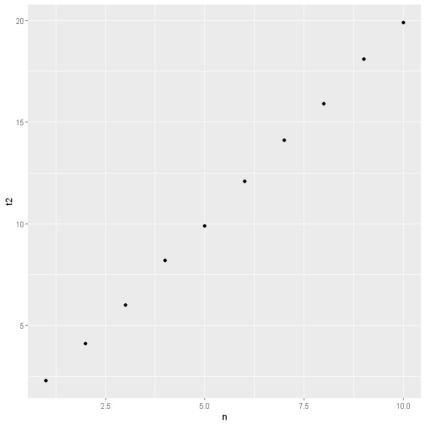

```r
a <- ggplot(results, aes(x=n, y=t2)) + geom_point()
a
# nie używamy "" w aes!
```

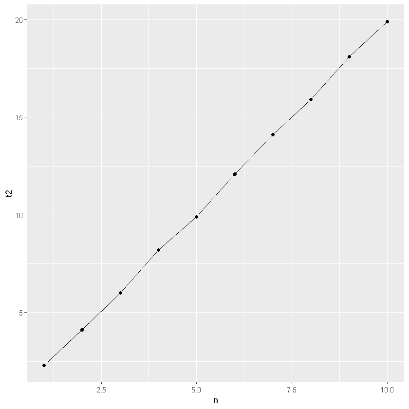

```r
a + geom_line()
# nie podano nic do geom_line więc wykorzystano argumenty do ggplot(...)
```

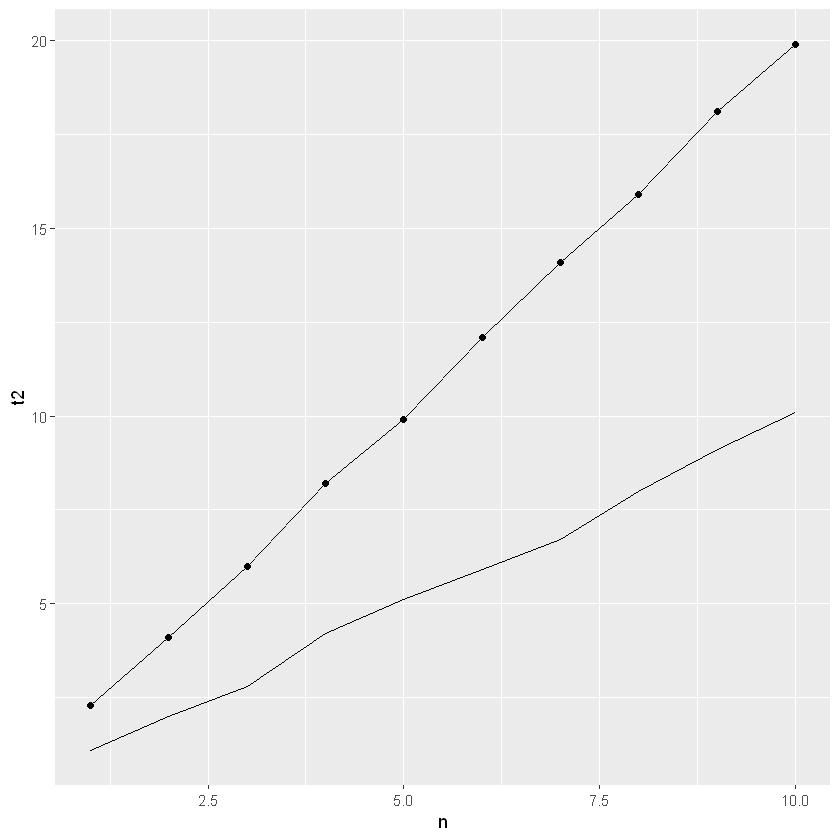

```r
last_plot() + geom_line(aes(x=n, y=t1))
# tutaj podano inny aes, ale dalej odnosimy się do "results"
```

## Przykład analizy danych w czystym R

Przetwarzanie danych w tabeli

Dane w pliku data2.txt mają postać tabeli faktów, w której wiersze są wynikami pomiarów.

Przykładowo, zmierzono czas (time) dla różnych algorytmów (t1, t2).

Kolumna `alg` jest typu `factor` - jest to typ wyliczeniowy w R.

```r
results <- read.csv("data2.txt")

results
```

| n | alg | time | error |
| --- | --- | --- | --- |
| 1 | t1 | 1.010572 | 0.010572148 |
| 2 | t1 | 1.981689 | -0.018310993 |
| 3 | t1 | 3.066268 | 0.066268043 |
| 4 | t1 | 4.060221 | 0.060220570 |
| 5 | t1 | 5.029502 | 0.029502051 |
| 6 | t1 | 6.045928 | 0.045927536 |
| 7 | t1 | 6.957461 | -0.042538559 |
| 8 | t1 | 8.009891 | 0.009891313 |
| 9 | t1 | 9.053959 | 0.053959370 |
| 10 | t1 | 9.982560 | -0.017439984 |
| 1 | t2 | 1.997585 | -0.002414813 |
| 2 | t2 | 3.953772 | -0.046227795 |
| 3 | t2 | 5.978172 | -0.021827928 |
| 4 | t2 | 8.052453 | 0.052453117 |
| 5 | t2 | 10.072778 | 0.072777961 |
| 6 | t2 | 11.957002 | -0.042997938 |
| 7 | t2 | 14.002079 | 0.002078900 |
| 8 | t2 | 16.031059 | 0.031058822 |
| 9 | t2 | 18.046717 | 0.046716672 |
| 10 | t2 | 20.046959 | 0.046959194 |
| 1 | t1 | 1.079367 | 0.079366812 |
| 2 | t1 | 2.034495 | 0.034494559 |
| 3 | t1 | 2.942990 | -0.057010017 |
| 4 | t1 | 3.936265 | -0.063734966 |
| 5 | t1 | 4.971931 | -0.028069105 |
| 6 | t1 | 5.935258 | -0.064741864 |
| 7 | t1 | 6.930239 | -0.069760726 |
| 8 | t1 | 8.088869 | 0.088868510 |
| 9 | t1 | 8.949670 | -0.050330255 |
| 10 | t1 | 9.963969 | -0.036030556 |
| ... | ... | ... | ... |
| 1 | t2 | 2.0298945 | 0.029894485 |
| 2 | t2 | 3.9258667 | -0.074133292 |
| 3 | t2 | 6.0798658 | 0.079865815 |
| 4 | t2 | 8.0427000 | 0.042699961 |
| 5 | t2 | 10.0047110 | 0.004710953 |
| 6 | t2 | 12.0451718 | 0.045171754 |
| 7 | t2 | 14.0277883 | 0.027788304 |
| 8 | t2 | 15.9948606 | -0.005139422 |
| 9 | t2 | 17.9814433 | -0.018556727 |
| 10 | t2 | 20.0706583 | 0.070658276 |
| 1 | t1 | 0.9608387 | -0.039161259 |
| 2 | t1 | 2.0267897 | 0.026789747 |
| 3 | t1 | 2.9177290 | -0.082271013 |
| 4 | t1 | 3.9467534 | -0.053246569 |
| 5 | t1 | 5.0340156 | 0.034015561 |
| 6 | t1 | 6.0447867 | 0.044786676 |
| 7 | t1 | 6.9471870 | -0.052813046 |
| 8 | t1 | 8.0205163 | 0.020516265 |
| 9 | t1 | 8.9359922 | -0.064007769 |
| 10 | t1 | 10.0013729 | 0.001372936 |
| 1 | t2 | 1.9076066 | -0.092393352 |
| 2 | t2 | 3.9216544 | -0.078345629 |
| 3 | t2 | 5.9047371 | -0.095262873 |
| 4 | t2 | 7.9451692 | -0.054830831 |
| 5 | t2 | 10.0706839 | 0.070683864 |
| 6 | t2 | 11.9154638 | -0.084536184 |
| 7 | t2 | 13.9948929 | -0.005107067 |
| 8 | t2 | 15.9483586 | -0.051641405 |
| 9 | t2 | 17.9686723 | -0.031327676 |
| 10 | t2 | 19.9371683 | -0.062831726 |

Dodanie nowej kolumny:

```r
results$speed <- results$n / results$time

results
```

| n | alg | time | error | speed |
| --- | --- | --- | --- | --- |
| 1 | t1 | 1.010572 | 0.010572148 | 0.9895385 |
| 2 | t1 | 1.981689 | -0.018310993 | 1.0092401 |
| 3 | t1 | 3.066268 | 0.066268043 | 0.9783880 |
| 4 | t1 | 4.060221 | 0.060220570 | 0.9851682 |
| 5 | t1 | 5.029502 | 0.029502051 | 0.9941342 |
| 6 | t1 | 6.045928 | 0.045927536 | 0.9924036 |
| 7 | t1 | 6.957461 | -0.042538559 | 1.0061141 |
| 8 | t1 | 8.009891 | 0.009891313 | 0.9987651 |
| 9 | t1 | 9.053959 | 0.053959370 | 0.9940402 |
| 10 | t1 | 9.982560 | -0.017439984 | 1.0017470 |
| 1 | t2 | 1.997585 | -0.002414813 | 0.5006044 |
| 2 | t2 | 3.953772 | -0.046227795 | 0.5058460 |
| 3 | t2 | 5.978172 | -0.021827928 | 0.5018256 |
| 4 | t2 | 8.052453 | 0.052453117 | 0.4967430 |
| 5 | t2 | 10.072778 | 0.072777961 | 0.4963874 |
| 6 | t2 | 11.957002 | -0.042997938 | 0.5017980 |
| 7 | t2 | 14.002079 | 0.002078900 | 0.4999258 |
| 8 | t2 | 16.031059 | 0.031058822 | 0.4990313 |
| 9 | t2 | 18.046717 | 0.046716672 | 0.4987057 |
| 10 | t2 | 20.046959 | 0.046959194 | 0.4988288 |
| 1 | t1 | 1.079367 | 0.079366812 | 0.9264691 |
| 2 | t1 | 2.034495 | 0.034494559 | 0.9830451 |
| 3 | t1 | 2.942990 | -0.057010017 | 1.0193715 |
| 4 | t1 | 3.936265 | -0.063734966 | 1.0161917 |
| 5 | t1 | 4.971931 | -0.028069105 | 1.0056455 |
| 6 | t1 | 5.935258 | -0.064741864 | 1.0109080 |
| 7 | t1 | 6.930239 | -0.069760726 | 1.0100661 |
| 8 | t1 | 8.088869 | 0.088868510 | 0.9890135 |
| 9 | t1 | 8.949670 | -0.050330255 | 1.0056237 |
| 10 | t1 | 9.963969 | -0.036030556 | 1.0036161 |
| ... | ... | ... | ... | ... |
| 1 | t2 | 2.0298945 | 0.029894485 | 0.4926364 |
| 2 | t2 | 3.9258667 | -0.074133292 | 0.5094416 |
| 3 | t2 | 6.0798658 | 0.079865815 | 0.4934319 |
| 4 | t2 | 8.0427000 | 0.042699961 | 0.4973454 |
| 5 | t2 | 10.0047110 | 0.004710953 | 0.4997646 |
| 6 | t2 | 12.0451718 | 0.045171754 | 0.4981249 |
| 7 | t2 | 14.0277883 | 0.027788304 | 0.4990095 |
| 8 | t2 | 15.9948606 | -0.005139422 | 0.5001607 |
| 9 | t2 | 17.9814433 | -0.018556727 | 0.5005160 |
| 10 | t2 | 20.0706583 | 0.070658276 | 0.4982398 |
| 1 | t1 | 0.9608387 | -0.039161259 | 1.0407574 |
| 2 | t1 | 2.0267897 | 0.026789747 | 0.9867822 |
| 3 | t1 | 2.9177290 | -0.082271013 | 1.0281969 |
| 4 | t1 | 3.9467534 | -0.053246569 | 1.0134912 |
| 5 | t1 | 5.0340156 | 0.034015561 | 0.9932429 |
| 6 | t1 | 6.0447867 | 0.044786676 | 0.9925909 |
| 7 | t1 | 6.9471870 | -0.052813046 | 1.0076021 |
| 8 | t1 | 8.0205163 | 0.020516265 | 0.9974420 |
| 9 | t1 | 8.9359922 | -0.064007769 | 1.0071629 |
| 10 | t1 | 10.0013729 | 0.001372936 | 0.9998627 |
| 1 | t2 | 1.9076066 | -0.092393352 | 0.5242171 |
| 2 | t2 | 3.9216544 | -0.078345629 | 0.5099888 |
| 3 | t2 | 5.9047371 | -0.095262873 | 0.5080666 |
| 4 | t2 | 7.9451692 | -0.054830831 | 0.5034506 |
| 5 | t2 | 10.0706839 | 0.070683864 | 0.4964906 |
| 6 | t2 | 11.9154638 | -0.084536184 | 0.5035473 |
| 7 | t2 | 13.9948929 | -0.005107067 | 0.5001825 |
| 8 | t2 | 15.9483586 | -0.051641405 | 0.5016190 |
| 9 | t2 | 17.9686723 | -0.031327676 | 0.5008717 |
| 10 | t2 | 19.9371683 | -0.062831726 | 0.5015757 |

Grupowanie (agregacja)

Przyklad: zastosowanie funkcji FUN (tutaj: mean czyli obliczającej średnią) do wszystkich wartosci time dla takich samych n i alg:

```r
avg_results <- aggregate(time ~ n:alg, data=results, FUN=mean)

avg_results
```

| n | alg | time |
| --- | --- | --- |
| 1 | t1 | 0.9990494 |
| 2 | t1 | 2.0152520 |
| 3 | t1 | 2.9867132 |
| 4 | t1 | 3.9869472 |
| 5 | t1 | 4.9716765 |
| 6 | t1 | 6.0127196 |
| 7 | t1 | 6.9400184 |
| 8 | t1 | 8.0313431 |
| 9 | t1 | 8.9836556 |
| 10 | t1 | 9.9948604 |
| 1 | t2 | 1.9878299 |
| 2 | t2 | 3.9599609 |
| 3 | t2 | 5.9861750 |
| 4 | t2 | 8.0300291 |
| 5 | t2 | 10.0251302 |
| 6 | t2 | 11.9724193 |
| 7 | t2 | 14.0112964 |
| 8 | t2 | 16.0212972 |
| 9 | t2 | 17.9699109 |
| 10 | t2 | 19.9883028 |

Dołączenie kolumny z obliczonym odchyleniem standardowym (sd) do tabeli:

```r
avg_results$sd <- aggregate(time ~ n:alg, data=results, FUN=sd)$time
```

```r
avg_results
```

| n | alg | time | sd |
| --- | --- | --- | --- |
| 1 | t1 | 0.9990494 | 0.04902917 |
| 2 | t1 | 2.0152520 | 0.04664671 |
| 3 | t1 | 2.9867132 | 0.07417292 |
| 4 | t1 | 3.9869472 | 0.08150832 |
| 5 | t1 | 4.9716765 | 0.06018547 |
| 6 | t1 | 6.0127196 | 0.04730261 |
| 7 | t1 | 6.9400184 | 0.01562886 |
| 8 | t1 | 8.0313431 | 0.05328619 |
| 9 | t1 | 8.9836556 | 0.04886179 |
| 10 | t1 | 9.9948604 | 0.06245583 |
| 1 | t2 | 1.9878299 | 0.06654991 |
| 2 | t2 | 3.9599609 | 0.04418932 |
| 3 | t2 | 5.9861750 | 0.06413231 |
| 4 | t2 | 8.0300291 | 0.04983246 |
| 5 | t2 | 10.0251302 | 0.04548820 |
| 6 | t2 | 11.9724193 | 0.05267832 |
| 7 | t2 | 14.0112964 | 0.05988583 |
| 8 | t2 | 16.0212972 | 0.05359947 |
| 9 | t2 | 17.9699109 | 0.05270112 |
| 10 | t2 | 19.9883028 | 0.07047764 |

Agregacja kilku wielkości:

```r
avg_results <- aggregate(cbind(time,speed) ~ n:alg, data=results, FUN=mean)
```

```r
avg_results
```

| n | alg | time | speed |
| --- | --- | --- | --- |
| 1 | t1 | 0.9990494 | 1.0028054 |
| 2 | t1 | 2.0152520 | 0.9928574 |
| 3 | t1 | 2.9867132 | 1.0049406 |
| 4 | t1 | 3.9869472 | 1.0036074 |
| 5 | t1 | 4.9716765 | 1.0058149 |
| 6 | t1 | 6.0127196 | 0.9979343 |
| 7 | t1 | 6.9400184 | 1.0086470 |
| 8 | t1 | 8.0313431 | 0.9961325 |
| 9 | t1 | 8.9836556 | 1.0018430 |
| 10 | t1 | 9.9948604 | 1.0005453 |
| 1 | t2 | 1.9878299 | 0.5035135 |
| 2 | t2 | 3.9599609 | 0.5051054 |
| 3 | t2 | 5.9861750 | 0.5012006 |
| 4 | t2 | 8.0300291 | 0.4981456 |
| 5 | t2 | 10.0251302 | 0.4987549 |
| 6 | t2 | 11.9724193 | 0.5011596 |
| 7 | t2 | 14.0112964 | 0.4996042 |
| 8 | t2 | 16.0212972 | 0.4993398 |
| 9 | t2 | 17.9699109 | 0.5008407 |
| 10 | t2 | 19.9883028 | 0.5002976 |

Filtrowanie danych:

```r
avg_results$alg=="t1"
```

1. TRUE

2. TRUE

3. TRUE

4. TRUE

5. TRUE

6. TRUE

7. TRUE

8. TRUE

9. TRUE

10. TRUE

11. FALSE

12. FALSE

13. FALSE

14. FALSE

15. FALSE

16. FALSE

17. FALSE

18. FALSE

19. FALSE

20. FALSE

```r
avg_results[avg_results$alg=="t1",]
```

| n | alg | time | speed |
| --- | --- | --- | --- |
| 1 | t1 | 0.9990494 | 1.0028054 |
| 2 | t1 | 2.0152520 | 0.9928574 |
| 3 | t1 | 2.9867132 | 1.0049406 |
| 4 | t1 | 3.9869472 | 1.0036074 |
| 5 | t1 | 4.9716765 | 1.0058149 |
| 6 | t1 | 6.0127196 | 0.9979343 |
| 7 | t1 | 6.9400184 | 1.0086470 |
| 8 | t1 | 8.0313431 | 0.9961325 |
| 9 | t1 | 8.9836556 | 1.0018430 |
| 10 | t1 | 9.9948604 | 1.0005453 |

Rysowanie wykresów.

Wykres time w funkcji n:

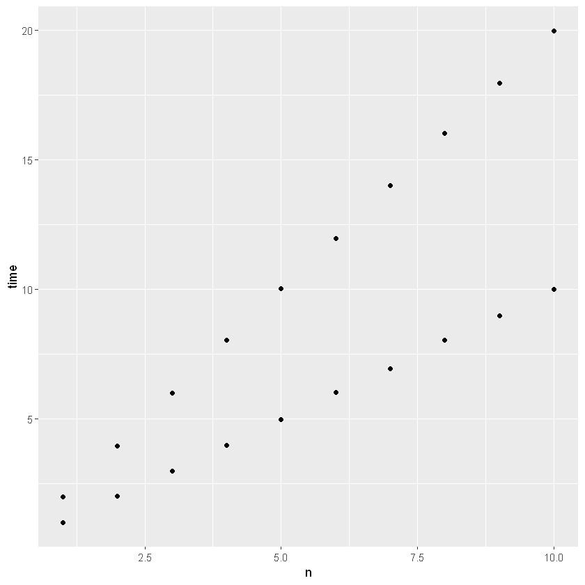

```r
ggplot(avg_results, aes(n,time)) + geom_point()
```

Przykład skryptu rysującego wykres.

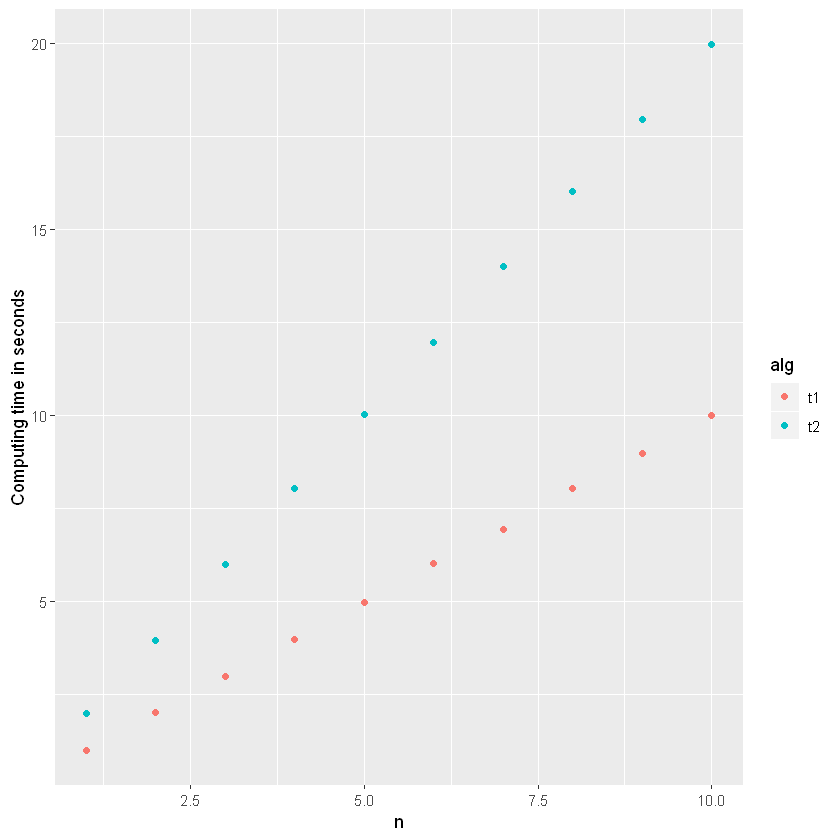

```r
results <- read.csv("data2.txt")
results$speed <- results$n / results$time
avg_results <- aggregate( cbind(time,speed) ~ n:alg, data=results, FUN=mean)
ggplot(avg_results, aes(n,time,color=alg)) + geom_point() + ylab("Computing time in seconds")
```

Możemy też uruchomić kod tworzący wykres z osobnego pliku

```r
source("data2_plot.R")
```

w bashu za pomoca polecenia:

`Rscript data2_plot.R`

W wyniku powstaje plik myplot.png

### Powyższy przykład z wykorzystaniem tidyverse

```r
results <- read_csv("data2.txt")
```

Operator `%>%` pozwala przekazywać wyjście z jednej funkcji jako wejście kolejnej, co pozwala na tworzenie łańcucha wywołań funkcji (analogiczne do '|' w bashu).

```r
avg_dplyr <- results %>%
    mutate(speed = n/time) %>% # tylko aby pokazać mutate, nie wykorzystujemy do plota
    group_by(n, alg) %>%
    summarise(
        time_sd = sd(time),
        time = mean(time),
        speed = mean(speed)
    )  %>%
    arrange(alg, n) #sortowanie
```

```r
avg_dplyr
```

| n | alg | time_sd | time | speed |
| --- | --- | --- | --- | --- |
| 1 | t1 | 0.04902917 | 0.9990494 | 1.0028054 |
| 2 | t1 | 0.04664671 | 2.0152520 | 0.9928574 |
| 3 | t1 | 0.07417292 | 2.9867132 | 1.0049406 |
| 4 | t1 | 0.08150832 | 3.9869472 | 1.0036074 |
| 5 | t1 | 0.06018547 | 4.9716765 | 1.0058149 |
| 6 | t1 | 0.04730261 | 6.0127196 | 0.9979343 |
| 7 | t1 | 0.01562886 | 6.9400184 | 1.0086470 |
| 8 | t1 | 0.05328619 | 8.0313431 | 0.9961325 |
| 9 | t1 | 0.04886179 | 8.9836556 | 1.0018430 |
| 10 | t1 | 0.06245583 | 9.9948604 | 1.0005453 |
| 1 | t2 | 0.06654991 | 1.9878299 | 0.5035135 |
| 2 | t2 | 0.04418932 | 3.9599609 | 0.5051054 |
| 3 | t2 | 0.06413231 | 5.9861750 | 0.5012006 |
| 4 | t2 | 0.04983246 | 8.0300291 | 0.4981456 |
| 5 | t2 | 0.04548820 | 10.0251302 | 0.4987549 |
| 6 | t2 | 0.05267832 | 11.9724193 | 0.5011596 |
| 7 | t2 | 0.05988583 | 14.0112964 | 0.4996042 |
| 8 | t2 | 0.05359947 | 16.0212972 | 0.4993398 |
| 9 | t2 | 0.05270112 | 17.9699109 | 0.5008407 |
| 10 | t2 | 0.07047764 | 19.9883028 | 0.5002976 |

Kolejność operacji w `summarise` ma znaczenie!

```r
# zamieniona kolejność mean i sd
results %>%
    group_by(n, alg) %>%
    summarise(
        time = mean(time),
        time_sd = sd(time) # sd jest liczone dla jednego wiersza po agregracji, stad NA w wynikach
    )  %>%
    arrange(alg, n)
```

| n | alg | time | time_sd |
| --- | --- | --- | --- |
| 1 | t1 | 0.9990494 | NA |
| 2 | t1 | 2.0152520 | NA |
| 3 | t1 | 2.9867132 | NA |
| 4 | t1 | 3.9869472 | NA |
| 5 | t1 | 4.9716765 | NA |
| 6 | t1 | 6.0127196 | NA |
| 7 | t1 | 6.9400184 | NA |
| 8 | t1 | 8.0313431 | NA |
| 9 | t1 | 8.9836556 | NA |
| 10 | t1 | 9.9948604 | NA |
| 1 | t2 | 1.9878299 | NA |
| 2 | t2 | 3.9599609 | NA |
| 3 | t2 | 5.9861750 | NA |
| 4 | t2 | 8.0300291 | NA |
| 5 | t2 | 10.0251302 | NA |
| 6 | t2 | 11.9724193 | NA |
| 7 | t2 | 14.0112964 | NA |
| 8 | t2 | 16.0212972 | NA |
| 9 | t2 | 17.9699109 | NA |
| 10 | t2 | 19.9883028 | NA |

Wykres rysowany jak poprzednio

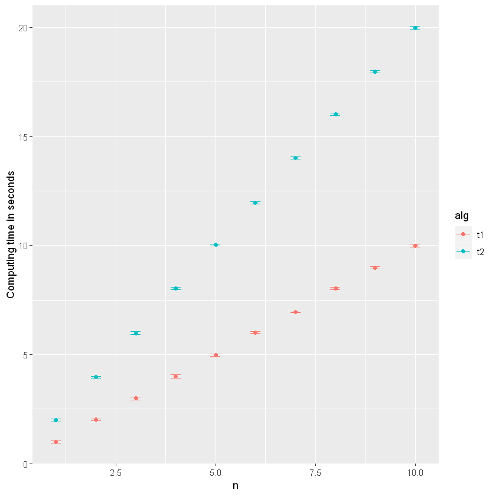

```r
ggplot(avg_dplyr, aes(n, time, color=alg)) + geom_point() + ylab("Computing time in seconds") +
    geom_errorbar(aes(ymin = time-time_sd, ymax = time+time_sd, width=.25))
```

Przykład filtrowania i wybierania kolumn

```r
# wybieranie wierszy spełniających warunek
avg_dplyr %>% filter(alg=="t1")
```

| n | alg | time_sd | time | speed |
| --- | --- | --- | --- | --- |
| 1 | t1 | 0.04902917 | 0.9990494 | 1.0028054 |
| 2 | t1 | 0.04664671 | 2.0152520 | 0.9928574 |
| 3 | t1 | 0.07417292 | 2.9867132 | 1.0049406 |
| 4 | t1 | 0.08150832 | 3.9869472 | 1.0036074 |
| 5 | t1 | 0.06018547 | 4.9716765 | 1.0058149 |
| 6 | t1 | 0.04730261 | 6.0127196 | 0.9979343 |
| 7 | t1 | 0.01562886 | 6.9400184 | 1.0086470 |
| 8 | t1 | 0.05328619 | 8.0313431 | 0.9961325 |
| 9 | t1 | 0.04886179 | 8.9836556 | 1.0018430 |
| 10 | t1 | 0.06245583 | 9.9948604 | 1.0005453 |

```r
avg_dplyr
```

| n | alg | time_sd | time | speed |
| --- | --- | --- | --- | --- |
| 1 | t1 | 0.04902917 | 0.9990494 | 1.0028054 |
| 2 | t1 | 0.04664671 | 2.0152520 | 0.9928574 |
| 3 | t1 | 0.07417292 | 2.9867132 | 1.0049406 |
| 4 | t1 | 0.08150832 | 3.9869472 | 1.0036074 |
| 5 | t1 | 0.06018547 | 4.9716765 | 1.0058149 |
| 6 | t1 | 0.04730261 | 6.0127196 | 0.9979343 |
| 7 | t1 | 0.01562886 | 6.9400184 | 1.0086470 |
| 8 | t1 | 0.05328619 | 8.0313431 | 0.9961325 |
| 9 | t1 | 0.04886179 | 8.9836556 | 1.0018430 |
| 10 | t1 | 0.06245583 | 9.9948604 | 1.0005453 |
| 1 | t2 | 0.06654991 | 1.9878299 | 0.5035135 |
| 2 | t2 | 0.04418932 | 3.9599609 | 0.5051054 |
| 3 | t2 | 0.06413231 | 5.9861750 | 0.5012006 |
| 4 | t2 | 0.04983246 | 8.0300291 | 0.4981456 |
| 5 | t2 | 0.04548820 | 10.0251302 | 0.4987549 |
| 6 | t2 | 0.05267832 | 11.9724193 | 0.5011596 |
| 7 | t2 | 0.05988583 | 14.0112964 | 0.4996042 |
| 8 | t2 | 0.05359947 | 16.0212972 | 0.4993398 |
| 9 | t2 | 0.05270112 | 17.9699109 | 0.5008407 |
| 10 | t2 | 0.07047764 | 19.9883028 | 0.5002976 |

```r
# wybór kolumn
avg_dplyr %>% ungroup() %>% select(time, speed) %>% head()
```

| time | speed |
| --- | --- |
| 0.9990494 | 1.0028054 |
| 2.0152520 | 0.9928574 |
| 2.9867132 | 1.0049406 |
| 3.9869472 | 1.0036074 |
| 4.9716765 | 1.0058149 |
| 6.0127196 | 0.9979343 |

```r
# usuwanie kolumn
avg_dplyr %>% select(-alg) %>% head()
```

| n | time_sd | time | speed |
| --- | --- | --- | --- |
| 1 | 0.04902917 | 0.9990494 | 1.0028054 |
| 2 | 0.04664671 | 2.0152520 | 0.9928574 |
| 3 | 0.07417292 | 2.9867132 | 1.0049406 |
| 4 | 0.08150832 | 3.9869472 | 1.0036074 |
| 5 | 0.06018547 | 4.9716765 | 1.0058149 |
| 6 | 0.04730261 | 6.0127196 | 0.9979343 |

## Zadanie

Za pomocą języka R przeanalizować dowolne dane z poprzednich laboratoriów. Elementy obowiązkowe:

1. W jednej tabeli języka R należy umieścić wyniki dwóch różnych eksperymentów (t.j. czas działania dwóch różnych funkcji) dla różnych parametrów (t.j. rozmiarów wektora(macierzy)). Tabela powinna zawierać dane z 10-krotnego uruchomienia tego samego eksperymentu dla tych samych parametrów (dla każdego takiego zestawu) **(1p.)**
2. Należy przedstawić wykresy średnich czasów obliczenia wybranych funkcji w zależności od rozmiaru wektora (macierzy) **(1p.)**
3. Wykresy powinny zawierać informację o odchyleniu standardowym dla uzyskanych wyników (słupki błędów) **(1p.)**